# Codebook draft for DBS and BIO vars

#### Distributions

Distributions are presented below for each subscale:

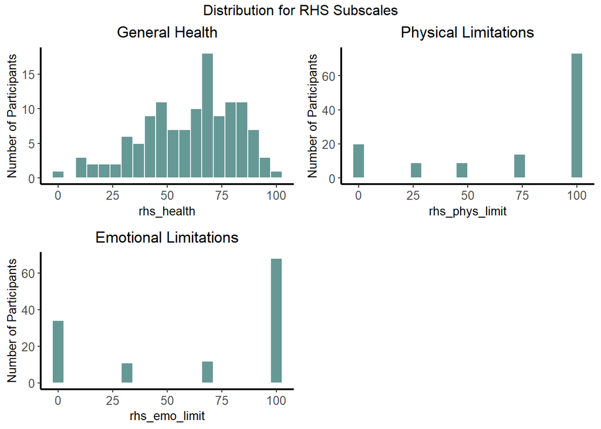

### COVID-19 Exposure and Vaccination (CEV) Description

There were no subscales computed since the CEV is not a standardized measure with developed subscales but meant to assess COVID-19 exposure. Similarly, no distributions or clinical categories are presented as no subscales were calculated.

### CEV Variables

#### Value labels

Variables `cev1` through `cev9` are dichotomous:

| 0 | 1 |
| --- | --- |
| No | Yes |

Value labels for `cev10` are below:

| 1 | 2 | 3 |
| --- | --- | --- |
| Johnson & Johnson | Moderna | Pfizer |

#### Survey Items

All CEV survey items are presented in the following table:

| Variable | Description |
| --- | --- |
| cev1 | Have you ever tested positive for COVID-19? |
| cev2 | Have you recently tested positive for COVID-19? (within the past 10 days?) |
| cev3 | Do you currently have any COVID-related symptoms that are not attributable to another condition, for example, a fever, loss of taste or smell, muscle aches, or cold or respiratory symptoms? |
| cev4 | Within the past 14 days, has a public health or medical professional told you to self-monitor, self-isolate, or self-quarantine because of concerns about COVID-19 infection? |
| cev5 | In the last two weeks, have you been exposed to someone who has tested positive for COVID-19? |
| cev6 | In the last two weeks, have you traveled outside of the U.S. or to a U.S. region with high COVID-19 rates? |
| cev7 | When I am in public spaces or in the community, I practice social distancing. |
| cev8 | When I am in public spaces or in the community, I wear my mask at all times. |
| cev9 | Have you had the COVID-19 vaccine? |
| cev10 | Which vaccine did you receive? |

#### Descriptive Statistics

Descriptive statistics are presented below for all CEV variables.

**Binary variables:**

| Variable | No N | No % | Yes N | Yes % | % Missing |  |
| --- | --- | --- | --- | --- | --- | --- |
| cev1 | 81 | 64.8% | 44 | 35.2% |  | 0% |
| cev2 | 125 | 100% | 0 | 0% | 0% |  |
| cev3 | 122 | 97.6% | 3 | 2.4% | 0% |  |
| cev4 | 122 | 97.6% | 3 | 2.4% | 0% |  |
| cev5 | 115 | 92% | 10 | 8% | 0% |  |
| cev6 | 123 | 98.4% | 0 | 0% | 1.6% |  |
| cev7 | 29 | 23.2% | 96 | 76.8% | 0% |  |
| cev8 | 76 | 60.8% | 47 | 37.6% | 1.6% |  |
| cev9 | 71 | 56.8% | 54 | 43.2% | 0% |  |

**Categorical variables:**

| Variable | Johnson & Johnson N | Johnson & Johnson % | Moderna N | Moderna % | Pfizer N | Pfizer % | % Missing |  |
| --- | --- | --- | --- | --- | --- | --- | --- | --- |
| cev10 | 7 | 5.6% | 26 | 20.8% | 19 | 15.2% |  | 58.4% |

### Health and Biological Confound (HBC) Description

The Health and Biological Confound (HBC) survey is a self-report measure designed to assess various health behaviors that could impact the biological data collection.

There were no subscales computed since the HBC is not a standardized measure with developed subscales but meant to assess potential health confounds related to the biological variables. Further, no descriptive statistics, distributions, or clinical categories are presented since these are not key study variables and there are no calculated subscales.

Note: There are many conditional questions in this data set, thus there are many “Not Applicable” responses (`-55`).

### HBC Variables

#### Value labels

Due to the quantity of HBC variables and different value labels, value labels are presented in the variable table below

#### Survey Items

All HBC survey items are presented in the following table. If the variable has value, labels those are presented in the last column, if there are no value labels the type of variable is listed.

| Variable | Description | Variable Type or Value Labels |
| --- | --- | --- |
| hbc1 | Minutes since last time participant ate anything | Continuous Variable |
| hbc2 | Are you currently feeling sick or ill? | 0 = No 1 = Yes |
| hbc3 | Do you currently have a cold or flu, or have you had a cold or flu within the past 7 days? | 0 = No 1 = Yes |
| hbc4 | Do you currently have a sinus infection, or have you had a sinus infection within the past 7 days? | 0 = No 1 = Yes |
| hbc5 | Do you currently have another type of infection (e.g., UTI, staph), or have you had an infection like this within the past 7 days? | 0 = No 1 = Yes |
| hbc6 | Do you currently have a large wound, injury, or broken bone? Have you had an injury in the past 7 days? | 0 = No 1 = Yes |
| hbc7 | In the past 7 days have you taken any over-the-counter medication for cold or flu? | 0 = No 1 = Yes |
| hbc7a | Did you take that medication today? | 0 = No 1 = Yes |
| hbc7b | If yes, what type of medication? | Open Text Variable |
| hbc7c | Minutes since medication was taken | Continuous Variable |
| hbc8 | In the past 7 days have you been prescribed or taken any antibiotics? | 0 = No 1 = Yes |
| hbc8a | Did you take that medication today? | 0 = No 1 = Yes |
| hbc8b | Minutes since medication was taken | Continuous Variable |
| hbc9 | In the past 7 days have you taken any NSAIDs, such as ibuprofen or aspirin? | 0 = No 1 = Yes |
| hbc9a | Did you take that medication today? | 0 = No 1 = Yes |
| hbc9b | Minutes since medication was taken | Continuous Variable |
| hbc9c | Which one did you take? | Open Text Variable |
| hbc10 | In the past 7 days have you taken any other medication? | 0 = No 1 = Yes |
| hbc10a | Did you take that medication today? | 0 = No 1 = Yes |
| hbc10b | Minutes since medication was taken | Continuous Variable |
| hbc11 | Do you take any other medications regularly, including birth control? | 0 = No 1 = Yes |
| hbc11a | Did you take that medication today? | 0 = No 1 = Yes |
| hbc11b | Minutes since medication was taken | Continuous Variable |
| hbc12 | Do you smoke cigarettes? | 0 = No 1 = Yes |
| hbc12a | About how much do you smoke per day? | 1 = 1 cigarette 2 = 2-5 cigarettes 3 = 1 pack 4 = 2 packs |
| hbc12b | Number of days since you last smoked | Continuous Variable |
| hbc12c | Minutes since you last smoked | Continuous Variable |
| hbc12d | How much did you smoke at that time? | 1 = 1 cigarette 2 = 2-5 cigarettes 3 = 1 pack 4 = 2 packs |
| hbc13 | Are you currently exposed to cigarette smoke from anyone in your household? | 0 = No 1 = Yes |
| hbc13a | How many hours per day were you exposed to second-hand smoke? | 1 = Never 2 = .5-1 hour/day 3 = 1-5 hours/day 4 = 5 or more hours/day |
| hbc14 | Are you currently exposed to cigarette smoke from anyone in your place of employment? | 0 = No 1 = Yes |
| hbc14a | How many hours per day were you exposed to second-hand smoke? | 1 = Never 2 = .5-1 hour/day 3 = 1-5 hours/day 4 = 5 or more hours/day |
| hbc15 | Are you currently exposed to cigarette smoke from anyone while in transportation, for example, driving to work, going to events, or while on public transit. | 0 = No 1 = Yes |
| hbc15a | How many hours per day were you exposed to second-hand smoke? | 1 = Never 2 = .5-1 hour/day 3 = 1-5 hours/day 4 = 5 or more hours/day |
| hbc16 | Are you currently exposed to cigarette smoke while at social, leisure, or recreational events? | 0 = No 1 = Yes |
| hbc16a | How many hours per day were you exposed to second-hand smoke? | 1 = Never 2 = .5-1 hour/day 3 = 1-5 hours/day 4 = 5 or more hours/day |
| hbc17 | Do you ever consume caffeine? | 0 = No 1 = Yes |
| hbc17a | If so, how much caffeine do you consume daily? | 1 = 0 cups or cans 2 = 1-3 cups or cans 3 = 4-6 cups or cans 4 = 7-9 cups or cans 5 = 10 or more cups or cans |
| hbc17b | Did you consume caffeine today? | 0 = No 1 = Yes |
| hbc17c | How much did you consume? | 1 = 0 cups or cans 2 = 1-3 cups or cans 3 = 4-6 cups or cans 4 = 7-9 cups or cans 5 = 10 or more cups or cans |
| hbc18 | Do you do any type of physical activity or exercise? | 0 = No 1 = Yes |
| hbc18a | What do you typically do? | Open Text Variable |
| hbc18b | How many days per week do you exercise? | Continuous Variable |
| hbc18c | For about how long do you exercise each time? (minutes) | Continuous Variable |
| hbc18d | Is your physical activity typically mild, moderate, or vigorous? | 1 = Mild 2 = Moderate 3 = Vigorous |
| hbc18e | Did you do any moderate or vigorous physical activity today? | 0 = No 1 = Yes |
| hbc18f | How many minutes ago did you exercise? | Continuous Variable |

### Chronic Health Conditions (CHC) Description

The Chronic Health Conditions (CHC) survey is a self-report measure designed to assess various health conditions that could impact the biological data collection.

There were no subscales computed since the CHC is not a standardized measure with developed subscales but meant to assess potential health confounds related to the biological variables. Further, no descriptive statistics, distributions, or clinical categories are presented since these are not key study variables and there are no calculated subscales.

Note: There are many conditional questions in this data set, thus there are many “Not Applicable” responses (`-55`).

### CHC Variables

#### Value labels

All CHC variables are dichotomous.

| 0 | 1 |
| --- | --- |
| No | Yes |

#### Survey Items

All CHC survey items are presented in the following table:

| Variable | Description |
| --- | --- |
| chc1a | Are you now or have you ever been treated for or diagnosed with heart conditions/heart disease? |
| chc1b | Were you diagnosed with this condition? |
| chc1c | Were you treated for this condition? |
| chc1d | Is it ongoing? |
| chc2a | Are you now or have you ever been treated or diagnosed with high blood pressure? |
| chc2b | Did this occur during pregnancy? |
| chc2c | Were you diagnosed for this condition? |
| chc2d | Were you treated for this condition? |
| chc2e | Is it ongoing? |
| chc3a | Are you now or have you ever been treated for or diagnosed with anemia? |
| chc3b | Were you diagnosed with this condition? |
| chc3c | Were you treated for this condition? |
| chc3d | Is it ongoing? |
| chc4a | Are you or have you ever been treated for or diagnosed with asthma? |
| chc4b | Were you diagnosed with this condition? |
| chc4c | Were you treated for this condition? |
| chc4d | Is it ongoing? |
| chc5a | Are you now or have you ever been treated for or diagnosed with other lung/breathing conditions? |
| chc5b | Were you diagnosed with this condition? |
| chc5c | Were you treated for this condition? |
| chc5d | Is it ongoing? |
| chc6a | Are you now or have you ever been treated for or diagnosed with high cholesterol? |
| chc6b | Were you diagnosed with this condition? |
| chc6c | Were you treated for this condition? |
| chc6d | Is it ongoing? |
| chc7a | Are you now or have you ever been treated for or diagnosed with diabetes? |
| chc7b | Were you diagnosed with this condition? |
| chc7c | Were you treated for this condition? |
| chc7d | Is it ongoing? |
| chc8a | Are you now or have you ever been treated for or diagnosed with obesity? |

[output cut: 51 more lines]